# 18-02. 문장 임베딩 기반 텍스트 랭크(TextRank Based on Sentence Embedding)

## 텍스트랭크(TextRank)

- 페이지랭크 알고리즘은 텍스트랭크 알고리즘의 기반
- 페이지랭크 알고리즘은 검색 엔진에서 웹 페이지의 순위를 정하기 위해 사용되던 알고리
- 텍스트랭크 알고리즘은 페이지랭크를 기반으로 한 텍스트 요약 알고리즘
- **텍스트랭크에서 그래프의 노드들은 문장들이며,**

  **각 간선의 가중치는 문장들 간의 유사도를 의미**

## 사전 훈련된 임베딩(Pre-trained Embedding)

### 사전 훈련된 GloVe 다운로드

```python
import numpy as np
import gensim
from urllib.request import urlretrieve, urlopen
import gzip
import zipfile
```

```python
urlretrieve("http://nlp.stanford.edu/data/glove.6B.zip", filename="glove.6B.zip")
zf = zipfile.ZipFile('glove.6B.zip')
zf.extractall()
zf.close()
```

```python
glove_dict = dict()
f = open('glove.6B.100d.txt', encoding="utf8") # 100차원의 GloVe 벡터를 사용

for line in f:
    word_vector = line.split()
    word = word_vector[0]
    word_vector_arr = np.asarray(word_vector[1:], dtype='float32') # 100개의 값을 가지는 array로 변환
    glove_dict[word] = word_vector_arr
f.close()
```

- 'cat`에 대한 임베딩 벡터

```python
glove_dict['cat']
```

```
array([ 0.23088  ,  0.28283  ,  0.6318   , -0.59411  , -0.58599  ,
        0.63255  ,  0.24402  , -0.14108  ,  0.060815 , -0.7898   ,
       -0.29102  ,  0.14287  ,  0.72274  ,  0.20428  ,  0.1407   ,
        0.98757  ,  0.52533  ,  0.097456 ,  0.8822   ,  0.51221  ,
        0.40204  ,  0.21169  , -0.013109 , -0.71616  ,  0.55387  ,
        1.1452   , -0.88044  , -0.50216  , -0.22814  ,  0.023885 ,
        0.1072   ,  0.083739 ,  0.55015  ,  0.58479  ,  0.75816  ,
        0.45706  , -0.28001  ,  0.25225  ,  0.68965  , -0.60972  ,
        0.19578  ,  0.044209 , -0.31136  , -0.68826  , -0.22721  ,
        0.46185  , -0.77162  ,  0.10208  ,  0.55636  ,  0.067417 ,
       -0.57207  ,  0.23735  ,  0.4717   ,  0.82765  , -0.29263  ,
       -1.3422   , -0.099277 ,  0.28139  ,  0.41604  ,  0.10583  ,
        0.62203  ,  0.89496  , -0.23446  ,  0.51349  ,  0.99379  ,
        1.1846   , -0.16364  ,  0.20653  ,  0.73854  ,  0.24059  ,
       -0.96473  ,  0.13481  , -0.0072484,  0.33016  , -0.12365  ,
        0.27191  , -0.40951  ,  0.021909 , -0.6069   ,  0.40755  ,
        0.19566  , -0.41802  ,  0.18636  , -0.032652 , -0.78571  ,
       -0.13847  ,  0.044007 , -0.084423 ,  0.04911  ,  0.24104  ,
        0.45273  , -0.18682  ,  0.46182  ,  0.089068 , -0.18185  ,
       -0.01523  , -0.7368   , -0.14532  ,  0.15104  , -0.71493  ],
      dtype=float32)
```

### 사전 훈련된 FastText 다운로드

```python
!pip install fasttext
```

```python
# 300차원의 FastText 벡터 사용
import fasttext.util
fasttext.util.download_model('en', if_exists='ignore')
ft = fasttext.load_model('cc.en.300.bin')
```

### 사전 훈련된 Word2Vec 다운로드

```python
# 300차원의 Word2Vec 벡터 사용
urlretrieve("https://s3.amazonaws.com/dl4j-distribution/GoogleNews-vectors-negative300.bin.gz", \
                           filename="GoogleNews-vectors-negative300.bin.gz")
word2vec_model = gensim.models.KeyedVectors.load_word2vec_format('GoogleNews-vectors-negative300.bin.gz', binary=True)
```

## 문장 임베딩(Sentence Embedding)

- 어떤 다수의 문장들을 서로 비교할 때, 문장들을 각 문장을 표현하는 고정된 길이의 벡터로 변환한다면 벡터 간 비교로 문장을 비교할 수 있음
- **`glove_dict`에는 100차원의 GloVe 벡터들이 저장되어져 있으며,**

  **OOV 문제. 즉, glove_dict에 존재하지 않는 단어가 문장에 존재할 경우 해당 단어의 임베딩값으로 사용할 100차원의 영벡터도 생성**

```python
embedding_dim = 100
zero_vector = np.zeros(embedding_dim)
```

- 문장의 각 단어를 사전 훈련된 GloVe 벡터로 변환하면서, OOV 문제가 발생할 경우에는 해당 단어를 영벡터로 변환

  $\rightarrow$ 그리고 이렇게 모인 단어 벡터들의 평균을 구하여 반환

```python
def calculate_sentence_vector(sentence):
  return sum([glove_dict.get(word, zero_vector) for word in sentence])/len(sentence)
```

```python
eng_sent = ['I', 'am', 'a', 'student']
sentence_vector = calculate_sentence_vector(eng_sent)
print(len(sentence_vector))
```

```
100
```

- **현재 사용하고 있는 사전 훈련된 GloVe는 영어에 대해서 학습된 임베딩**

  $\rightarrow$ **한국어를 넣으면 당연히 모든 단어에 대해서 OOV 문제가 발생**

  $\rightarrow$ **모든 단어가 영벡터이므로 평균을 구해도 영벡터가 반환**

```python
kor_sent = ['전', '좋은', '학생', '입니다']
sentence_vector = calculate_sentence_vector(kor_sent)
print(sentence_vector)
```

```
[0. 0. 0. 0. 0. 0. 0. 0. 0. 0. 0. 0. 0. 0. 0. 0. 0. 0. 0. 0. 0. 0. 0. 0.
 0. 0. 0. 0. 0. 0. 0. 0. 0. 0. 0. 0. 0. 0. 0. 0. 0. 0. 0. 0. 0. 0. 0. 0.
 0. 0. 0. 0. 0. 0. 0. 0. 0. 0. 0. 0. 0. 0. 0. 0. 0. 0. 0. 0. 0. 0. 0. 0.
 0. 0. 0. 0. 0. 0. 0. 0. 0. 0. 0. 0. 0. 0. 0. 0. 0. 0. 0. 0. 0. 0. 0. 0.
 0. 0. 0. 0.]
```

## 텍스트 랭크를 이용한 텍스트 요약

```python
import numpy as np
import re
import pandas as pd
import matplotlib.pyplot as plt
from nltk.tokenize import sent_tokenize, word_tokenize
from nltk.corpus import stopwords
from urllib.request import urlretrieve
import zipfile
from sklearn.metrics.pairwise import cosine_similarity
import networkx as nx
```

- `NLTK` 제공 불용어

```python
import nltk
nltk.download('stopwords')
nltk.download('punkt')

stop_words = stopwords.words('english')
```

#### 데이터 로드

- 텍스트 요약에 사용할 테니스 관련 기사를 다운로드하고, 데이터프레임에 저장
- 총 3개의 열이 존재하지만 여기서 사용할 열은 기사 본문에 해당하는 `article_text`

```python
urlretrieve("https://raw.githubusercontent.com/prateekjoshi565/textrank_text_summarization/master/tennis_articles_v4.csv", filename="tennis_articles_v4.csv")
data = pd.read_csv("tennis_articles_v4.csv")
data.head()
```

|  | article_id | article_text | source |
| --- | --- | --- | --- |
| 0 | 1 | Maria Sharapova has basically no friends as te... | https://www.tennisworldusa.org/tennis/news/Mar... |
| 1 | 2 | BASEL, Switzerland (AP), Roger Federer advance... | http://www.tennis.com/pro-game/2018/10/copil-s... |
| 2 | 3 | Roger Federer has revealed that organisers of ... | https://scroll.in/field/899938/tennis-roger-fe... |
| 3 | 4 | Kei Nishikori will try to end his long losing ... | http://www.tennis.com/pro-game/2018/10/nishiko... |
| 4 | 5 | Federer, 37, first broke through on tour over ... | https://www.express.co.uk/sport/tennis/1036101... |

- `article_text`열만 사용하기로 하고, 해당 기사를 문장 토큰화한 결과를 저장한 sentences라는 열을 새로 생성

```python
data = data[['article_text']]
data['sentences'] = data['article_text'].apply(sent_tokenize)
data
```

|  | article_text | sentences |
| --- | --- | --- |
| 0 | Maria Sharapova has basically no friends as te... | [Maria Sharapova has basically no friends as t... |
| 1 | BASEL, Switzerland (AP), Roger Federer advance... | [BASEL, Switzerland (AP), Roger Federer advanc... |
| 2 | Roger Federer has revealed that organisers of ... | [Roger Federer has revealed that organisers of... |
| 3 | Kei Nishikori will try to end his long losing ... | [Kei Nishikori will try to end his long losing... |
| 4 | Federer, 37, first broke through on tour over ... | [Federer, 37, first broke through on tour over... |
| 5 | Nadal has not played tennis since he was force... | [Nadal has not played tennis since he was forc... |
| 6 | Tennis giveth, and tennis taketh away. The end... | [Tennis giveth, and tennis taketh away., The e... |
| 7 | Federer won the Swiss Indoors last week by bea... | [Federer won the Swiss Indoors last week by be... |

#### 토큰화와 전처리를 위한 함수

- 토큰화 함수

```python
def tokenization(sentences):
    return [word_tokenize(sentence) for sentence in sentences]
```

- 전처리 함수

```python
def preprocess_sentence(sentence):

  # 영어를 제외한 숫자, 특수 문자 등은 전부 제거. 모든 알파벳은 소문자화
  sentence = [re.sub(r'[^a-zA-z\s]', '', word).lower() for word in sentence]
  # 불용어가 아니면서 단어가 실제로 존재해야 한다.
  return [word for word in sentence if word not in stop_words and word]
```

- 위 전처리 함수를 모든 문장에 대해서 수행. 이 함수를 호출하면 모든 행에 대해서 수행

```python
def preprocess_sentences(sentences):
    return [preprocess_sentence(sentence) for sentence in sentences]
```

```python
data['tokenized_sentences'] = data['sentences'].apply(tokenization)
data['tokenized_sentences'] = data['tokenized_sentences'].apply(preprocess_sentences)
data
```

|  | article_text | sentences | tokenized_sentences |
| --- | --- | --- | --- |
| 0 | Maria Sharapova has basically no friends as te... | [Maria Sharapova has basically no friends as t... | [[maria, sharapova, basically, friends, tennis... |
| 1 | BASEL, Switzerland (AP), Roger Federer advance... | [BASEL, Switzerland (AP), Roger Federer advanc... | [[basel, switzerland, ap, roger, federer, adva... |
| 2 | Roger Federer has revealed that organisers of ... | [Roger Federer has revealed that organisers of... | [[roger, federer, revealed, organisers, relaun... |
| 3 | Kei Nishikori will try to end his long losing ... | [Kei Nishikori will try to end his long losing... | [[kei, nishikori, try, end, long, losing, stre... |
| 4 | Federer, 37, first broke through on tour over ... | [Federer, 37, first broke through on tour over... | [[federer, first, broke, tour, two, decades, a... |
| 5 | Nadal has not played tennis since he was force... | [Nadal has not played tennis since he was forc... | [[nadal, played, tennis, since, forced, retire... |
| 6 | Tennis giveth, and tennis taketh away. The end... | [Tennis giveth, and tennis taketh away., The e... | [[tennis, giveth, tennis, taketh, away], [end,... |
| 7 | Federer won the Swiss Indoors last week by bea... | [Federer won the Swiss Indoors last week by be... | [[federer, swiss, indoors, last, week, beating... |

- 사용할 GloVe 벡터의 차원은 100 $→$ 100차원의 영벡터를 생성

```python
embedding_dim = 100
zero_vector = np.zeros(embedding_dim)
```

- 단어 벡터의 평균을 구하는 함수를 정의
  - 단, 문장 길이가 0일 경우에는 100차원의 영벡터를 반환
  - 현재 불용어를 제거하였기 때문에 문장의 모든 단어가 불용어인 경우에는 길이가 0인 문장이 생길 수 있기 때문

```python
def calculate_sentence_vector(sentence):
  if len(sentence) != 0:
    return sum([glove_dict.get(word, zero_vector) for word in sentence])/len(sentence)
  else:
    return zero_vector
```

- 모든 문장에 대해서 수행하는 함수를 정의

```python
def sentences_to_vectors(sentences):
    return [calculate_sentence_vector(sentence) for sentence in sentences]
```

- 모든 문장에 대해서 문장 벡터를 생성

```python
data['SentenceEmbedding'] = data['tokenized_sentences'].apply(sentences_to_vectors)
data[['SentenceEmbedding']]
```

|  | SentenceEmbedding |
| --- | --- |
| 0 | [[0.051488996, 0.1105585, 0.6950863, 0.1891917... |
| 1 | [[0.10566062456928194, -0.10534465219825506, 0... |
| 2 | [[-0.022272188, -0.0474477, 0.14933074, -0.086... |
| 3 | [[0.045201838, -0.064647146, 0.5035717, -0.160... |
| 4 | [[0.21536233, 0.180915, 0.25600883, 0.06924241... |
| 5 | [[0.04484453, -0.0074302587, 0.33349112, -0.07... |
| 6 | [[-0.115338005, -0.0062844106, 0.595185, -0.16... |
| 7 | [[0.0740439, 0.059211146, 0.49143884, 0.216771... |

#### 유사도 계산

- **문장 벡터들 간의 코사인 유사도를 구한 유사도 행렬 생성**
  - 이 유사도 행렬의 크기는 (문장개수 $\times$ 문장개수)

```python
def similarity_matrix(sentence_embedding):

  sim_mat = np.zeros([len(sentence_embedding), len(sentence_embedding)])

  for i in range(len(sentence_embedding)):
      for j in range(len(sentence_embedding)):
        sim_mat[i][j] = cosine_similarity(sentence_embedding[i].reshape(1, embedding_dim),
                                          sentence_embedding[j].reshape(1, embedding_dim))[0,0]
  return sim_mat
```

```python
data['SimMatrix'] = data['SentenceEmbedding'].apply(similarity_matrix)
data['SimMatrix']
```

```
0    [[1.0, 0.6477208137512207, 0.5915699601173401,...
1    [[1.0000000000000002, 0.8745531210608369, 0.80...
2    [[0.9999998807907104, 0.913085401058197, 0.899...
3    [[0.9999999403953552, 0.7769179305294039, 0.84...
4    [[0.9999999403953552, 0.8306209732530097, 0.90...
5    [[1.0, 0.8843014240264893, 0.8540289072721128,...
6    [[1.0, 0.473054975271225, 0.45002683997154236,...
7    [[1.0000001192092896, 0.7634095600081803, 0.78...
Name: SimMatrix, dtype: object
```

- 두번째 샘플을 기준으로 지금까지 만든 열들의 크기를 확인

```python
print('두번째 샘플의 문장 개수 :',len(data['tokenized_sentences'][1]))
print('두번째 샘플의 문장 벡터가 모인 문장 행렬의 크기(shape) :',np.shape(data['SentenceEmbedding'][1]))
print('두번째 샘플의 유사도 행렬의 크기(shape) :',data['SimMatrix'][1].shape)
```

```
두번째 샘플의 문장 개수 : 12
두번째 샘플의 문장 벡터가 모인 문장 행렬의 크기(shape) : (12, 100)
두번째 샘플의 유사도 행렬의 크기(shape) : (12, 12)
```

#### 유사도 행렬 시각화

- 문장 개수가 12개 $→$ 총 12개의 노드

```python
def draw_graphs(sim_matrix):

  nx_graph = nx.from_numpy_array(sim_matrix)
  plt.figure(figsize=(10, 10))
  pos = nx.spring_layout(nx_graph)
  nx.draw(nx_graph, with_labels=True, font_weight='bold')
  nx.draw_networkx_edge_labels(nx_graph,pos,font_color='red')
  plt.show()
```

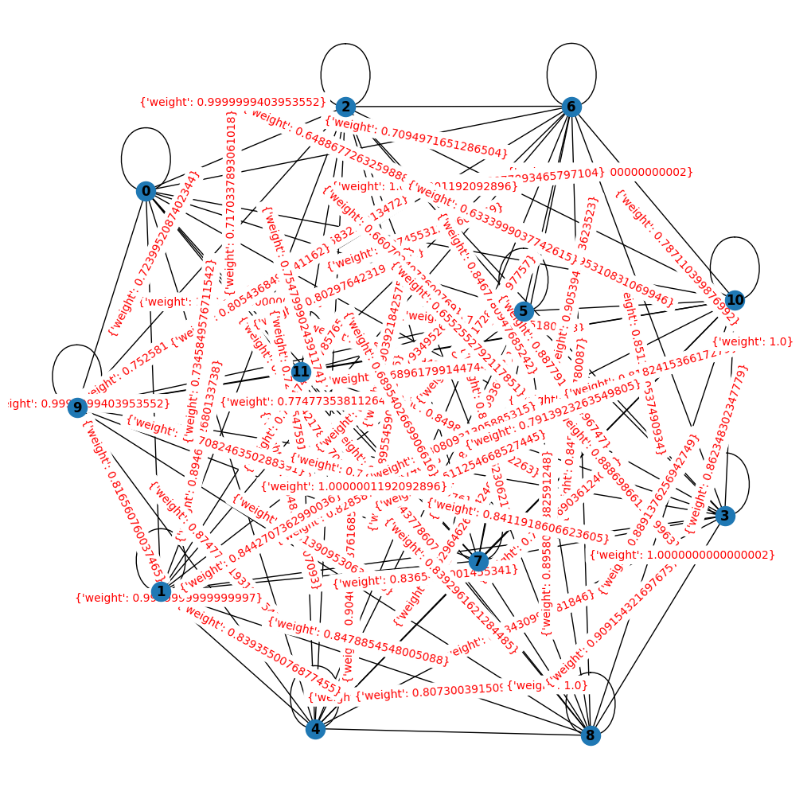

```python
draw_graphs(data['SimMatrix'][1])
```

- 그래프를 페이지랭크 알고리즘의 입력으로 사용하여, 각 문장의 점수를 계산

```python
def calculate_score(sim_matrix):
    nx_graph = nx.from_numpy_array(sim_matrix)
    scores = nx.pagerank(nx_graph)
    return scores
```

```python
data['score'] = data['SimMatrix'].apply(calculate_score)
data[['SimMatrix', 'score']]
```

|  | SimMatrix | score |
| --- | --- | --- |
| 0 | [[1.0, 0.6477208137512207, 0.5915699601173401,... | {0: 0.054921591857231694, 1: 0.062865197127825... |
| 1 | [[1.0000000000000002, 0.8745531210608369, 0.80... | {0: 0.0831509438964348, 1: 0.08498611318825285... |
| 2 | [[0.9999998807907104, 0.913085401058197, 0.899... | {0: 0.06148440450562715, 1: 0.0622486436175160... |
| 3 | [[0.9999999403953552, 0.7769179305294039, 0.84... | {0: 0.08164728322073438, 1: 0.0727647939629649... |
| 4 | [[0.9999999403953552, 0.8306209732530097, 0.90... | {0: 0.05568689673271279, 1: 0.0509923171787943... |
| 5 | [[1.0, 0.8843014240264893, 0.8540289072721128,... | {0: 0.08288694384176991, 1: 0.0840376031405664... |
| 6 | [[1.0, 0.473054975271225, 0.45002683997154236,... | {0: 0.07336251821036095, 1: 0.1050889009405666... |
| 7 | [[1.0000001192092896, 0.7634095600081803, 0.78... | {0: 0.043210395251217094, 1: 0.047333397704124... |

- 두 번째 샘플의 각 문장의 점수

```python
data['score'][1]
```

```
{0: 0.0831509438964348,
 1: 0.08498611318825285,
 2: 0.0855501969882867,
 3: 0.08383717254942684,
 4: 0.0813793988323122,
 5: 0.0843928498199495,
 6: 0.08507725733330257,
 7: 0.08092839239693102,
 8: 0.07454046010944942,
 9: 0.08535837210459046,
 10: 0.08498242787885528,
 11: 0.08581641490220814}
```

#### 요약문 생성

- **점수가 가장 높은 문장들을 상위 n개 선택하여, 이 문서의 요약문으로 생성**
- 점수가 가장 높은 상위 3개의 문장을 선택하는 함수

  점수에 따라서 정렬 후에 상위 3개 문장만을 반환

```python
def ranked_sentences(sentences, scores, n=3):
    top_scores = sorted(((scores[i],s) for i,s in enumerate(sentences)), reverse=True)
    top_n_sentences = [sentence for score,sentence in top_scores[:n]]
    return " ".join(top_n_sentences)
```

```python
data['summary'] = data.apply(lambda x: ranked_sentences(x.sentences, x.score), axis=1)
```

- 원문과 요약문 출력

```python
for i in range(0, len(data)):
  print(i+1,'번 문서')
  print('원문 :',data.loc[i].article_text)
  print('')
  print('요약 :',data.loc[i].summary)
  print('')
```

```
1 번 문서
원문 : Maria Sharapova has basically no friends as tennis players on the WTA Tour. The Russian player has no problems in openly speaking about it and in a recent interview she said: 'I don't really hide any feelings too much. I think everyone knows this is my job here. When I'm on the courts or when I…

요약 : I think just because you're in the same sport doesn't mean that you have to be friends with everyone just because you're categorized, you're a tennis player, so you're going to get along with tennis players. When I'm on the courts or when I'm on the court playing, I'm a competitor and I want to…

2 번 문서
원문 : BASEL, Switzerland (AP), Roger Federer advanced to the 14th Swiss Indoors final of his career by beating seventh-seeded Daniil Medvedev 6-1, 6-4 on Saturday. Seeking a ninth title at his hometown event, and a 99th overall, Federer will play 93th-ranked Marius Copil on Sunday. Federer dominated …

요약 : Federer had an easier time than in his only previous match against Medvedev, a three-setter at Shanghai two weeks ago. Federer dominated the 20th-ranked Medvedev and had his first match-point chance to break serve again at 5-1. Copil fired 26 aces past Zverev and never dropped serve, clinching …

3 번 문서
원문 : Roger Federer has revealed that organisers of the re-launched and condensed Davis Cup gave him three days to decide if he would commit to the controversial competition. Speaking at the Swiss Indoors tournament where he will play in Sundays final against Romanian qualifier Marius Copil, the worl…

요약 : Major players feel that a big event in late November combined with one in January before the Australian Open will mean too much tennis and too little rest. Speaking at the Swiss Indoors tournament where he will play in Sundays final against Romanian qualifier Marius Copil, the world number thre…

4 번 문서
원문 : Kei Nishikori will try to end his long losing streak in ATP finals and Kevin Anderson will go for his second title of the year at the Erste Bank Open on Sunday. The fifth-seeded Nishikori reached his third final of 2018 after beating Mikhail Kukushkin of Kazakhstan 6-4, 6-3 in the semifinals. A…

요약 : Kei Nishikori will try to end his long losing streak in ATP finals and Kevin Anderson will go for his second title of the year at the Erste Bank Open on Sunday. The Spaniard broke Anderson twice in the second but didn't get another chance on the South African's serve in the final set. He has lo…

5 번 문서
원문 : Federer, 37, first broke through on tour over two decades ago and he has since gone on to enjoy a glittering career. The 20-time Grand Slam winner is chasing his 99th ATP title at the Swiss Indoors this week and he faces Jan-Lennard Struff in the second round on Thursday (6pm BST). Davenport en…

요약 : "Not always, but I really feel like in the mid-2000 years there was a huge shift of the attitudes of the top players and being more friendly and being more giving, and a lot of that had to do with players like Roger coming up. "I felt like the best weeks that I had to get to know players when I…

6 번 문서
원문 : Nadal has not played tennis since he was forced to retire from the US Open semi-finals against Juan Martin Del Porto with a knee injury. The world No 1 has been forced to miss Spain's Davis Cup clash with France and the Asian hard court season. But with the ATP World Tour Finals due to begin ne…

요약 : Nadal's appearance in Paris is a big boost to the tournament organisers who could see Roger Federer withdraw. Federer's projected route to the Paris final could also lead to matches against Kevin Anderson and Novak Djokovic. But as it stands, Federer is in the draw and is scheduled to face eith…

7 번 문서
원문 : Tennis giveth, and tennis taketh away. The end of the season is finally in sight, and with so many players defending,or losing,huge chunks of points in Singapore, Zhuhai and London, podcast co-hosts Nina Pantic and Irina Falconi discuss the art of defending points (02:14). It's no secret that J…

요약 : Let's also not forget his two Grand Slam doubles triumphs this season. The end of the season is finally in sight, and with so many players defending,or losing,huge chunks of points in Singapore, Zhuhai and London, podcast co-hosts Nina Pantic and Irina Falconi discuss the art of defending point…

8 번 문서
원문 : Federer won the Swiss Indoors last week by beating Romanian qualifier Marius Copil in the final. The 37-year-old claimed his 99th ATP title and is hunting the century in the French capital this week. Federer has been handed a difficult draw where could could come across Kevin Anderson, Novak Dj…

요약 : "We also had the impression that at this stage it might be better to play matches than to train. "Maybe I should celebrate as if it were my last title. "On Monday, I am free and will look how I feel," Federer said after winning the Swiss Indoors.
```